# Transcriptomic signatures of sepsis severity

# Unsupervised methods

#### K-means clustering

First using k-means to see if there is any clusters

```r
set.seed(1)
sepsis.cluster.2 <- kmeans(top.data.imputed[,-1], 2, nstart=20)
print("K-means clustering for aim1 with k=2")
```

[1] “K-means clustering for aim1 with k=2”

```r
print(table(sepsis.cluster.2$cluster,top.data.imputed$aim1_status))
```

```
 1  2
```

1 31 14 2 50 27

```r
sepsis.cluster.4 <- kmeans(top.data.imputed[,-1], 4, nstart=20)
print("K-means clustering for aim1 with k=4")
```

[1] “K-means clustering for aim1 with k=4”

```r
print(table(sepsis.cluster.4$cluster,top.data.imputed$aim1_status))
```

```
 1  2
```

1 24 12 2 13 8 3 25 10 4 19 11

#### PCA

Use PCA to check batch effects with the scan date, then to see any useful clusters get formed

```r
sepsis.pca <- prcomp(top.data.imputed[,-1], center=TRUE, scale. = TRUE)
summary(sepsis.pca)
```

Importance of components%s: PC1 PC2 PC3 PC4 PC5 PC6 Standard deviation 2.6720 1.23185 1.1609 1.10579 1.04819 1.0308 Proportion of Variance 0.3104 0.06598 0.0586 0.05316 0.04777 0.0462 Cumulative Proportion 0.3104 0.37640 0.4350 0.48816 0.53593 0.5821 PC7 PC8 PC9 PC10 PC11 PC12 Standard deviation 1.02036 0.97472 0.95225 0.91482 0.84110 0.82132 Proportion of Variance 0.04527 0.04131 0.03943 0.03639 0.03076 0.02933 Cumulative Proportion 0.62740 0.66870 0.70813 0.74452 0.77528 0.80460 PC13 PC14 PC15 PC16 PC17 PC18 Standard deviation 0.81065 0.7778 0.75351 0.72457 0.67844 0.61260 Proportion of Variance 0.02857 0.0263 0.02469 0.02283 0.02001 0.01632 Cumulative Proportion 0.83318 0.8595 0.88417 0.90699 0.92700 0.94332 PC19 PC20 PC21 PC22 PC23 Standard deviation 0.60929 0.54836 0.52021 0.43877 0.41057 Proportion of Variance 0.01614 0.01307 0.01177 0.00837 0.00733 Cumulative Proportion 0.95946 0.97253 0.98430 0.99267 1.00000

```r
# Projecting data on the first 2 principal components
library(ggfortify)
print("Checking for batch effect with Scan Date")
```

[1] “Checking for batch effect with Scan Date”

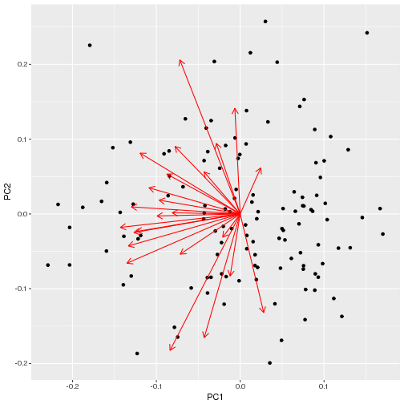

```r
top.data.scanDate <- top.data.imputed
top.data.scanDate$Scan_Date <- pData(top.eset)$Scan_Date
autoplot(prcomp(top.data.scanDate[,-25],center = TRUE, scale. = TRUE),
         data=top.data.scanDate, color=top.data.scanDate$Scan_Date, loadings = TRUE)
```

```r
print("PCA to discover any relevant clusters for aim 1")
```

[1] “PCA to discover any relevant clusters for aim 1”

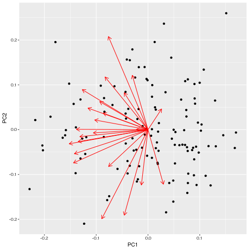

```r
autoplot(prcomp(top.data.imputed[,-1], center = TRUE, scale. = TRUE),
         data = top.data.imputed, color = "aim1_status", loadings = TRUE)
```

## Linear Discriminant Analysis (LDA) based on unadjusted model

```r
library(MASS)
sepsis.lda <- lda(aim1_status ~., top.data.imputed)
sepsis.lda.values <- predict(sepsis.lda)
print(sepsis.lda)
```

Call: lda(aim1_status ~ ., data = top.data.imputed)

Prior probabilities of groups: 1 2 0.6639344 0.3360656

Group means: aim2_short sex race_ethnicity X16650001 X16650003 X16650005 1 2.238149 1.432099 3.033973 3.061383 3.086646 3.813390 2 2.107793 1.487805 3.024228 3.025160 3.027884 3.711868 X16650007 X16650009 X16650011 X16650013 X16650015 X16650017 X16650019 1 3.502081 2.099930 3.538619 6.066543 6.321833 4.277396 3.895024 2 3.350023 2.183979 3.505772 6.071618 6.480757 4.404408 4.107927 X16650021 X16650023 X16650025 X16650027 X16650029 X16650031 X16650033 1 4.219426 3.904597 4.735147 2.801159 4.183327 5.326677 1.894958 2 4.244351 3.836133 4.622795 2.632897 4.164874 5.372157 1.848296 X16650035 X16650037 X16650041 1 2.037049 2.046465 6.451281 2 2.263521 2.110056 6.515827

Coefficients of linear discriminants: LD1 aim2_short 0.06381674 sex 0.34830226 race_ethnicity -0.12374453 X16650001 -0.28172860 X16650003 -0.60844442 X16650005 -0.35073881 X16650007 -0.54034120 X16650009 0.92158961 X16650011 -0.29900333 X16650013 0.20730995 X16650015 1.20004065 X16650017 -0.15577932 X16650019 0.30461088 X16650021 -0.25566326 X16650023 -0.46651872 X16650025 -1.09564969 X16650027 -0.62672956 X16650029 -0.16002344 X16650031 0.21799980 X16650033 -0.26569555 X16650035 1.01353803 X16650037 0.96216289 X16650041 0.14663453

## LDA histograms

```r
print("Stacked histogram of LDA values for first PC")
```

```
## [1] "Stacked histogram of LDA values for first PC"
```

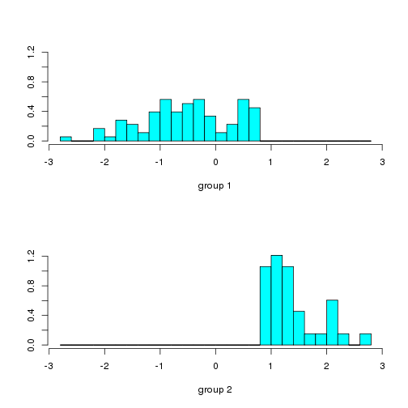

```r
ldahist(data=sepsis.lda.values$x[,1], g=sepsis.lda.values$class)
```

```r
cat("Stacked histogram of LDA values for second PC")
```

```
## Stacked histogram of LDA values for second PC
```

```r
ldahist(data=sepsis.lda.values$x[,2], g=sepsis.lda.values$class)
```

```
## Error in sepsis.lda.values$x[, 2]: subscript out of bounds
```

```r
cat("Scatterplot of Discriminant functions")
```

```
## Scatterplot of Discriminant functions
```

```r
plot(sepsis.lda.values$x[,1], sepsis.lda.values$x[,2])
```

```
## Error in sepsis.lda.values$x[, 2]: subscript out of bounds
```

```r
text(sepsis.lda.values$x[,1], sepsis.lda.values$x[,2], sepsis.lda.values$class, pos=4, col='red')
```

```
## Error in sepsis.lda.values$x[, 2]: subscript out of bounds
```

We proceeded to conduct 3-fold CV with LDA for aim1 (pressor_fluid vs. no_shock)

```r
library(pROC)
library(caret)
lda_sepsis <- function(data, target, n){
  set.seed(1)
  folds <- createFolds(data[[target]], k = n, list = TRUE, returnTrain = FALSE)
  sens <- spec <- accu <- numeric(n)
  N <- nrow(data)
  preds <- obs <- vector(mode="numeric", length = N)
  offset <- 0
  for (i in 1:n){
    train <- data[-folds[[i]],]
    test <- data[folds[[i]],]
    train.lda <- eval(parse(text=paste0("lda(", target, " ~ ., data=train)")))
    test.lda <- predict(train.lda, newdata = test)
    CM <- caret::confusionMatrix(test[[target]], test.lda$class)
    sens[i] <- CM$byClass[1]
    spec[i] <- CM$byClass[2]
    accu[i] <- CM$overall[1]
    obs[1:length(folds[[i]]) + offset] <- test[[target]]
    preds[1:length(folds[[i]]) + offset] <- as.numeric(levels(test.lda$class))[test.lda$class]
    offset <- offset + length(folds[[i]])
  }
  # Plot the ROC curve
  roc(obs, preds, ci=TRUE)
  plot.roc(obs, preds, ci=TRUE, col="red")
}
# Checking covariance of each class
X <- top.data.imputed[,-1]
print(paste("Covariance of no_shock samples", cov(x = X[X$aim1_status=="no_shock"])))
```

[1] “Covariance of no_shock samples ”

```r
print(paste("Covariance of pressor_fluid samples", cov(x = X[X$aim1_status=="pressor_fluid"])))
```

[1] “Covariance of pressor_fluid samples ”

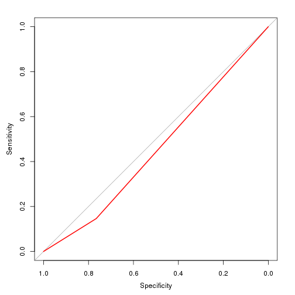

```r
# Using top.data.imputed
lda_sepsis(data = top.data.imputed, target = "aim1_status", n=3)
```

```r
# Using full.data, usually too heavy to run
# lda_sepsis(data = full.data, target = "aim1_status", n=3)
```

```r
print("Meanwhile, held-out CV gives the result:\n")
```

[1] “Meanwhile, held-out CV gives the result:\n”

```r
pressor.lda <- lda(aim1_status ~ ., data=top.data.imputed, CV=TRUE)
confusion <- caret::confusionMatrix(top.data$aim1_status, pressor.lda$class)
print(paste("Sensitivity: ", confusion$byClass[1]))
```

[1] “Sensitivity: 0.648351648351648”

```r
print(paste("Specificity: ", confusion$byClass[2]))
```

[1] “Specificity: 0.290322580645161”

```r
print(paste("Accuracy: ", confusion$overall[1]))
```

[1] “Accuracy: 0.557377049180328”

## Random Forests results

Applying Random Forests for aim1_status classfication 3-fold CV and ROC curve for Random Forests

```r
library(randomForest)
# Cross-Validation
random_forest <- function(data, target, n){
  set.seed(252)
  N = nrow(data)
  pred_outputs.rf <- obs_outputs <- vector(mode="numeric", length=N)
  offset <- 0
  folds <- createFolds(data[[target]], k = n, list = TRUE, returnTrain = FALSE)
  for(i in 1:n){
    train <- data[-folds[[i]],]
    test <- data[folds[[i]],]
    obs_outputs[1:length(folds[[i]]) + offset] <- test[[target]]
    # RF train/test
    rf <- eval(parse(text=paste0("randomForest(", target, "~., data=train, ntree=100)")))
    rf.pred.curr <- predict(rf, newdata=test, type="response")
    pred_outputs.rf[1:length(folds[[i]]) + offset] <- rf.pred.curr
    offset <- offset + length(folds[[i]])
  }
  print(paste("ROC plot: Random Forests for", target))
  roc(obs_outputs, pred_outputs.rf, ci=TRUE)
  plot.roc(obs_outputs, pred_outputs.rf, ci=TRUE, col="red")
}

random_forest(data = top.data.imputed, target="aim1_status", n=3)
```

[1] “ROC plot: Random Forests for aim1_status”

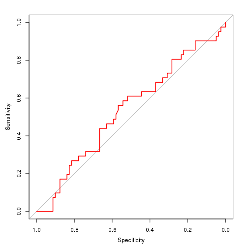

```r
print("Random Forests with clinical variables only")
```

[1] “Random Forests with clinical variables only”

```r
random_forest(data = full.data.imputed[,1:17], target = "aim1_status", n = 3)
```

[1] “ROC plot: Random Forests for aim1_status”

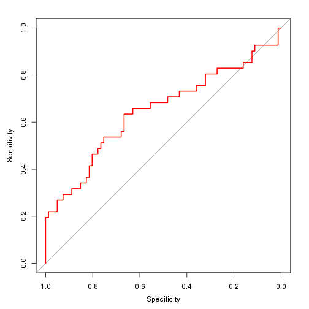

## KNN results

Trying out KNN with 1 nearest neighbor

```r
library(FNN)
knn_run <- function(data, target, n){
  set.seed(1)
  folds <- createFolds(data[[target]], k = n, list = TRUE, returnTrain = FALSE)
  N <- nrow(data)
  preds <- obs <- vector(mode="numeric", length = N)
  offset <- 0
  for (i in 1:n){
    train <- data[-folds[[i]],]
    test <- data[folds[[i]],]
    res <- knn(train, test, train[[target]], k=1, prob=FALSE, algorithm=c("kd_tree", "cover_tree", "brute"))
    obs[1:length(folds[[i]]) + offset] <- test[[target]]
    preds[1:length(folds[[i]]) + offset] <- as.numeric(levels(res))[res]
    offset <- offset + length(folds[[i]])
  }
  # Plot the ROC curve
  print(paste("KNN plot for", target))
  roc(obs, preds, ci=TRUE)
  plot.roc(obs, preds, ci=TRUE, col="red")
}
knn_run(data = top.data.imputed, target = "aim1_status", n=3)
```

[1] “KNN plot for aim1_status”

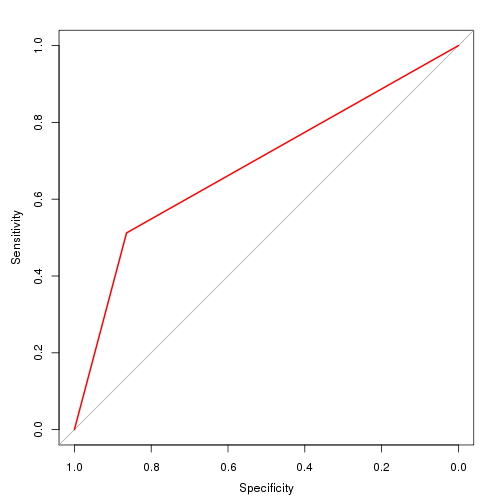